# Toothfish

## Toothfish Assessment

This document aims to reproduce a Toothfish assessment.

```r
library(Grym)
library(ggplot2)
library(dplyr)
library(furrr)
set.seed(31)
```

## Survey Data

Recruitment is backprojected from survey data. In this case natural mortality is assumed constant, so it suffices to backproject the recruitment once and use the same recruitment series in all projections.

Import the survey data

```r
survey.df <- read.csv(textConnection("
Survey,Year,Frac,Age,Density,SE,Area,ObsTotal,ExpTotal
1,1989,0.49,3,0.01,0.01,53383.16,70.32,74.57
1,1989,0.49,4,30.56,8.96,53383.16,70.32,74.57
1,1989,0.49,5,6.83,7.13,53383.16,70.32,74.57
1,1989,0.49,6,0.01,0.01,53383.16,70.32,74.57
1,1989,0.49,7,0.01,0.01,53383.16,70.32,74.57
2,1992,0.77,3,8.01,8.97,53383.16,67.54,85.22
2,1992,0.77,4,27.06,12.9,53383.16,67.54,85.22
2,1992,0.77,5,0.01,0.01,53383.16,67.54,85.22
2,1992,0.77,6,16.8,19.26,53383.16,67.54,85.22
2,1992,0.77,7,5.66,21.84,53383.16,67.54,85.22
3,1998,0.33,3,25.85,7.63,80660.77,373.59,371.54
3,1998,0.33,4,0.01,0.01,80660.77,373.59,371.54
3,1998,0.33,5,85.13,65.51,80660.77,373.59,371.54
3,1998,0.33,6,174.83,104.99,80660.77,373.59,371.54
3,1998,0.33,7,0.01,0.01,80660.77,373.59,371.54
3,1998,0.33,8,66.34,31.68,80660.77,373.59,371.54
4,2000,0.48,3,27.32,8.31,85693.96,198.46,200.63
4,2000,0.48,4,5.8,15.56,85693.96,198.46,200.63
4,2000,0.48,5,59.59,35.74,85693.96,198.46,200.63
4,2000,0.48,6,32.98,47.78,85693.96,198.46,200.63
4,2000,0.48,7,29.64,30.16,85693.96,198.46,200.63
5,2001,0.48,3,14.4,9.37,85693.96,207.12,206.07
5,2001,0.48,4,47.26,17.19,85693.96,207.12,206.07
5,2001,0.48,5,0.01,0.01,85693.96,207.12,206.07
5,2001,0.48,6,101.72,42.56,85693.96,207.12,206.07
5,2001,0.48,7,9.3,37.05,85693.96,207.12,206.07
6,2002,0.42,3,24.57,10.36,42063.96,142.77,140.1
6,2002,0.42,4,28.16,23.4,42063.96,142.77,140.1
6,2002,0.42,5,18.55,30.15,42063.96,142.77,140.1
6,2002,0.42,6,56.89,21.35,42063.96,142.77,140.1
7,2003,0.43,3,0.01,0.01,85123.46,234.65,231.64
7,2003,0.43,4,102.51,28.86,85123.46,234.65,231.64
7,2003,0.43,5,24.19,66,85123.46,234.65,231.64
7,2003,0.43,6,54.69,74.47,85123.46,234.65,231.64
8,2004,0.43,3,0.01,0.01,85693.96,240.42,241.79
8,2004,0.43,4,0.01,0.01,85693.96,240.42,241.79
8,2004,0.43,5,168.88,29.37,85693.96,240.42,241.79
8,2004,0.43,6,20.36,29.24,85693.96,240.42,241.79
9,2005,0.47,3,0.01,0.01,85693.96,173.09,175.94
9,2005,0.47,4,52.75,11.17,85693.96,173.09,175.94
9,2005,0.47,5,0.01,0.01,85693.96,173.09,175.94
9,2005,0.47,6,99.76,18.49,85693.96,173.09,175.94"),header=T)
```

The `SurveyAdjust` function scales the survey densities to abundance, computes the adjustment scale abundance to recruitment based survival, and form the weighted geometric means of the estimates of recruitment.

```r
SurveyAdjust <- function(survey.df,Ms,M,rec.age) {
  ## Scale density to abundance
  r <- survey.df$Area*survey.df$ObsTotal/survey.df$ExpTotal
  ab.mn <- r*survey.df$Density
  ab.se <- r*survey.df$SE

  ## Compute log survival adjustment
  inc <- ceiling((nrow(Ms)-1)*survey.df$Frac)+1
  S <- surveySurvival(survey.df$Year,survey.df$Age,inc,inc,Ms,M,rcls=rec.age)

  ## Weight rescaled abundance by 1/cv^2
  ab.wt <- (ab.mn/ab.se)^2
  ## Compute the year of "recruitment" to the target age class
  rc.yr <- survey.df$Year-survey.df$Age+rec.age
  yr <- seq.int(min(rc.yr),max(rc.yr))
  rec.yf <- factor(rc.yr,yr)
  ## Compute the weighted geometric means
  data.frame(
    Year=yr,
    Rec=exp(tapply(ab.wt*(log(ab.mn)-log(S)),rec.yf,sum)/tapply(ab.wt,rec.yf,sum)))
}
```

Form natural mortalities and compute recruitment estimates.

```r
## Constant intra-annual natural mortality
nsteps <- 24
Ages <- 4:35
Days <- seq(0,1,length=nsteps+1)
h <- 1/nsteps
ms <- matrix(1,nsteps+1,length(Ages))
Ms <- ctrapz(ms,h)
M <- 0.13
recruit.df <- SurveyAdjust(survey.df,Ms,M,4)
recruit.df
     Year          Rec
1986 1986 7.934563e+02
1987 1987 6.967303e+02
1988 1988 4.178565e+05
1989 1989 1.628287e+06
1990 1990 1.303211e+04
1991 1991 5.340455e+02
1992 1992 1.268959e+06
1993 1993 3.298331e+05
1994 1994 9.451050e+06
1995 1995 1.250968e+03
1996 1996 1.920454e+07
1997 1997 6.297719e+06
1998 1998 1.550252e+04
1999 1999 3.826884e+06
2000 2000 1.221262e+06
2001 2001 2.890527e+06
2002 2002 1.329131e+06
2003 2003 1.116513e+07
2004 2004 9.064134e+02
2005 2005 3.267711e+06
2006 2006 7.900025e+02
```

## Catch

Import the corresponding catch data

```r
catch.df <- read.csv(textConnection("
Year,Catch
1986,0
1987,0
1988,0
1989,0
1990,0
1991,0
1992,0
1993,0
1994,0
1995,3000000
1996,9044000
1997,7915000
1998,3974000
1999,4720000
2000,4984000
2001,6245000
2002,4356000
2003,3501000
2004,3048000
2005,2696000"),header=T)
```

## Growth

Growth patterns are inferred from length at age data.

Import the length at age data

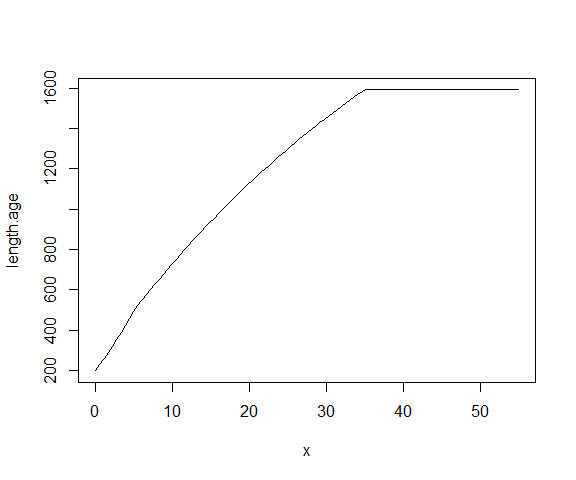

```r
length.df <- read.csv(textConnection("
Age, Length
0, 197.56
1, 251.01
2, 307.54
3, 367.28
4, 430.40
5, 497.03
6, 547.46
7, 594.75
8, 641.07
9, 686.46
10, 730.91
11, 774.47
12, 817.13
13, 858.93
14, 899.88
15, 940.00
16, 979.29
17, 1017.79
18, 1055.51
19, 1092.46
20, 1128.65
21, 1164.11
22, 1198.85
23, 1232.88
24, 1266.22
25, 1298.88
26, 1330.87
27, 1362.22
28, 1392.92
29, 1423.00
30, 1452.47
31, 1481.34
32, 1509.62
33, 1537.33
34, 1564.47
35, 1591.06"),header=T)
length.age <- approxfun(length.df$Age,length.df$Length,rule=2)
plot(length.age,0,55)
```

## Interpolation

Create an age or length based array through interpolation

```r
approxArray <- function(x,y,arr,rule=2) array(approx(x,y,arr,rule=rule)$y,dim(arr))
```

## Selectivity

Selectivity varies with year, and may be length or age based. This function creates a list of selectivity matrices together with an index vector that matches year to the appropriate selectivity.

```r
mkSelectivity <- function(ages,ls) {
  select5pt <- function(x) approxArray(x,c(0,0,1,1,0),ages)

  ## Age based selectivity
  ss <- list()
  ## 1986-1994 - age based selectivity
  ss[[1]] <- approxArray(x=c(0.0,4.1,4.9,5.8,7.0,8.4,9.8,13.7,14.9,16.1,17.3,18.4),
                         y=c(0.0,0.0,0.14,0.5,0.8,0.9,1.0,1.0,0.9,0.85,0.4,0.3),
                         ages)
  ## 1995 - length based selectivity
  ss[[2]] <- rampOgive(ls,670,250)
  ## 1996 - age based selectivity
  ss[[3]] <- select5pt(c(0.0,5.8,7.0,8.2,8.4))
  ## 1997 - age based selectivity
  ss[[4]] <- select5pt(c(0.0,4.9,5.8,11.1,13.7))
  ## 1998 - age based selectivity
  ss[[5]] <- select5pt(c(0.0,5.3,5.8,14.9,17.3))
  ## 1999-2004 - age based selectivity
  ss[[6]] <- select5pt(c(0.0,4.1,8.4,16.1,17.3))

  ## Year 1 = 1986
  list(index=setNames(c(rep(1,9),2:5,rep(6,6),1),1986:2005),ss=ss)
}
```

## Model

The arguments are

- `Catches` - the catch targets to test
- `Catch.df` - dataframe of historic catches - this must contain the catches for each year from the earliest modelled year upto the first projected year, ordered by year.
- `Recruit.df` - dataframe of recruitment estimates from survey data.
- `Length.df` - dataframe of length at age data.
- `n.years` - the number of years to project ahead
- `Year1` - the earliest modelled year.

```r
ToothfishProjection <- function(Catches,catch.df,recruit.df,length.df,n.years=35,Year1=min(catch.df$Year)) {

  ## Daily time steps with 8 age classes
  nsteps <- 24
  Ages <- 4:35
  plus <- 55-35
  Days <- seq(0,1,length=nsteps+1)
  h <- 1/nsteps

  ## Spawning and monitoring interval
  spawnI <- 14:15
  monitorI <- 1:25

  ## Ages, length at age and weight at age
  ages <- outer(Days,Ages,FUN="+")
  ls <- approxArray(length.df$Age,length.df$Length,ages)
  ws <- powerLW(ls,2.59E-9,3.2064)

  ## Build selectivity matrices
  sel <- mkSelectivity(ages,ls)
  current.sel <- -1

  ## Constant intra-annual natural mortality
  ms <- matrix(1,nsteps+1,length(Ages))
  Ms <- ctrapz(ms,h)
  Msf <- final(Ms)
  M <- 0.13
  MMs <- M*Ms

  ## Length based maturity
  gs <- rampOgive(ls,930,300)

  ## Within year fishing pattern
  fwy <- double(nsteps+1)
  fwy[] <- 1
  fwy <- fwy/mean(fwy)

  ## Calculate recruitment parameters from historic data
  ## By method of moments
  rmn <- mean(recruit.df$Rec,na.rm=TRUE)
  rsd <- sd(recruit.df$Rec,na.rm=TRUE)
  rmn <- 3016520
  rsd <- 1.62693*rmn
  rlsd <- sqrt(log(1+(rsd/rmn)^2))
  rlmn <- log(rmn)-rlsd^2/2
  ## By maximum likelihood
  #rlmn <- mean(log(recruit.df$Rec))
  #rlsd <- sd(log(recruit.df$Rec))

  ## Drop missing and out of range recruitment estimates
  recruit.df <- recruit.df[(recruit.df$Year %in% seq(Year1,length.out=nrow(catch.df)+n.years)) &
                             !is.na(recruit.df$Rec),]

  ## This function performs a projection for each prescribed gamma.
  function(run) {

    ## Median spawning biomass estimated from 1000 samples
    R <- matrix(rlnorm(1000*(length(Msf)+plus),rlmn,rlsd),1000,length(Msf)+plus)
    ssb0 <- spawningB0S(R,gs,ws,Ms,M,spawn=spawnI,plus=TRUE)

    ## Stochastic initial age structure in the absence of fishing
    N0 <- ageStructureS(rlnorm(length(Msf)+plus,rlmn,rlsd),Msf,M,plus=TRUE)
    ## Initial projection assuming no fishing
    pr <- project(ws,MMs,Nref=N0,yield=0)
    pr$F <- pr$Y <- 0

    ## Recruitment series - log Normal + known from survey
    Rs <- rlnorm(nrow(catch.df)+n.years,rlmn,rlsd)
    Rs[recruit.df$Year-Year1+1] <- recruit.df$Rec

    ## Annual summary quantities
    n <- nrow(catch.df)+n.years*length(Catches)
    Test<-rep(Catches, each=n/length(Catches))
    Year <- integer(n)
    Target <- R <- N <- B <- SSN <- SSB <- Catch <- F <- double(n)
    k <- 1

    ## Project over historic period
    for(yr in 1:nrow(catch.df)) {

      ## Recompute fishing mortality when selectivity changes
      if(sel$index[yr]!=current.sel) {
        current.sel <- sel$index[yr]
        ss <- sel$ss[[current.sel]]
        fs <- fwy*ss
        Fs <- ctrapz(fs,h)
      }

      ## Project over year
      Year[k] <- catch.df$Year[yr]
      Target[k] <- catch.df$Catch[yr]
      R[k] <- Rs[yr]
      N0 <- advance(pr$N,R[k],plus=TRUE)
      pr <- projectC(ws,MMs,Fs,fs,Target[k],Nref=N0,yield=1,Fmax=5,tol=1.0E-8)

      ## Collate annual summaries
      N[k] <- sum(initial(pr$N))
      B[k] <- sum(initial(pr$B))
      SSN[k] <- spawningStock(pr$N,gs,spawnI)
      SSB[k] <- spawningStock(pr$B,gs,spawnI)
      Catch[k] <- sum(pr$Y)
      F[k] <- pr$F
      k <- k+1
    }

    ## Record pre-projection state
    pr0 <- pr

    ## Set projection selectivity
    ss <- sel$ss[[1]]
    fs <- fwy*ss
    Fs <- ctrapz(fs,h)


    ## Project for each catch
    for(catch in Catches) {
      ## Reset to pre-projection state
      pr <- pr0


      for(yr in seq(nrow(catch.df)+1,length.out = n.years)) {
        ## Project over year
        N0 <- advance(pr$N,Rs[yr],plus=TRUE)
        pr <- projectC(ws,MMs,Fs,fs,catch,Nref=N0,yield=1,Fmax=5,tol=1.0E-8)
        #if(pr$F==5) return(NULL)

        ## Collate annual summaries
        Year[k] <- yr+Year1-1
        Target[k] <- catch
        R[k] <- Rs[yr]
        N[k] <- sum(initial(pr$N))
        B[k] <- sum(initial(pr$B))
        SSN[k] <- spawningStock(pr$N,gs,spawnI)
        SSB[k] <- spawningStock(pr$B,gs,spawnI)
        Catch[k] <- sum(pr$Y)
        F[k] <- pr$F
        k <- k+1
      }
    }
    data.frame(Run=run,M=M,Year=Year,Target=Target,
               R=R,N=N,B=B,SSN=SSN,SSB=SSB,SSB0=ssb0$median,Catch=Catch,F=F)
  }
}
```

## Projection

Calling `ToothfishProjection` returns a function that generates a single “run” of the simulation

```r
sim <- ToothfishProjection(Catches=c(0,2.8e6,2.84e6,2.85e6,2.9e6,3e6,3.2e6),
                           catch.df=catch.df,recruit.df=recruit.df,length.df=length.df)
```

```r
df <- sim(1)
head(df)
  Run    M Year Target            R        N         B     SSN       SSB
1   1 0.13 1986      0     793.4563 34769330 176689869 5418126 109073800
2   1 0.13 1987      0     696.7303 30531487 177471092 5400367 108686188
3   1 0.13 1988      0  417856.4639 27227415 177616471 5390025 108450808
4   1 0.13 1989      0 1628287.3915 25536557 178025628 5460165 108827578
5   1 0.13 1990      0   13032.1096 22436566 176922314 5612460 110046538
6   1 0.13 1991      0     534.0455 19701980 174677055 5765963 111447481
       SSB0 Catch F
1 108424390     0 0
2 108424390     0 0
3 108424390     0 0
4 108424390     0 0
5 108424390     0 0
6 108424390     0 0
tail(df)
    Run    M Year  Target          R        N         B     SSN      SSB
260   1 0.13 2035 3200000  3334818.4 16491925 109695862 4722877 82586762
261   1 0.13 2036 3200000   622256.5 14656005 106168139 4366360 80198302
262   1 0.13 2037 3200000  2136375.8 14512850 103161687 3998310 77390914
263   1 0.13 2038 3200000 18270760.6 30512466 111959212 3604884 73847964
264   1 0.13 2039 3200000  2405634.0 28637368 113940837 3259330 70326821
265   1 0.13 2040 3200000  4851693.6 29262139 116424353 2990282 67233282
         SSB0   Catch          F
260 108424390 3200000 0.06803536
261 108424390 3200000 0.07039509
262 108424390 3200000 0.07132475
263 108424390 3200000 0.07043870
264 108424390 3200000 0.06355163
265 108424390 3200000 0.05617647
```

For these parameters, the recruitment variability has greater impact than increased fishing pressure

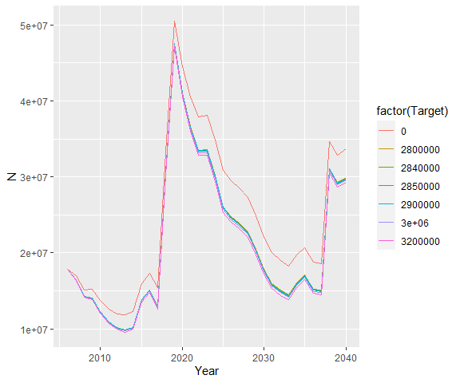

```r
ggplot(df %>% filter(Year > 2005),aes(x=Year,y=N,colour=factor(Target)))+geom_line()
```

Generate 100 runs and bind them into one large dataframe. The runs are performed in parallel with the `furrr` library. We use 100 runs here to show the concept most assessments would have a lot more, eg 10,000

```r
plan(multiprocess)
system.time(df <- future_map_dfr(1:100,sim))
   user  system elapsed
   0.25    0.05   16.62
```

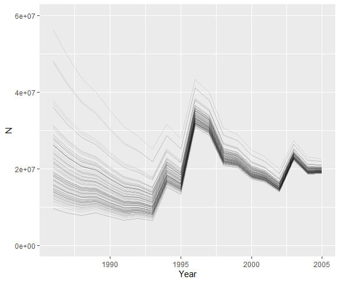

```r
ggplot(df %>% filter(Year <= 2005),
       aes(x=Year,y=N,group=Run))+
  geom_line(colour=rgb(0,0,0,0.1))+ylim(0,6E07)
```

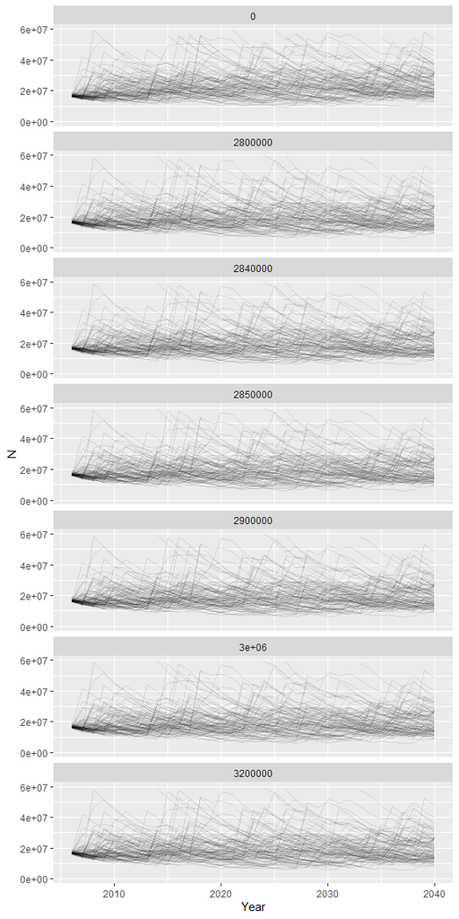

```r
ggplot(df %>% filter(Year > 2005),
       aes(x=Year,y=N,group=Run))+
  geom_line(colour=rgb(0,0,0,0.1))+
  facet_wrap(~Target,ncol=1)+ylim(0,6E07)
```

Calculate median escapement with quantiles.

```r
grymssb<-df %>%
  filter(Year==2040) %>%
  mutate(Status=SSB/SSB0) %>%
  group_by(Target/1000) %>%
  summarise(q2.5=quantile(Status,0.025),
            q45=quantile(Status,0.45),
            q50=quantile(Status,0.50),
            q55=quantile(Status,0.55),
            q97.5=quantile(Status,0.975),
            Median=median(Status)) %>%
  mutate(Model="Grym")

grymssb
# A tibble: 7 x 8
  `Target/1000`  q2.5   q45   q50   q55 q97.5 Median Model
          <dbl> <dbl> <dbl> <dbl> <dbl> <dbl>  <dbl> <chr>
1             0 0.661 0.997 1.03  1.06   1.84  1.03  Grym
2          2800 0.240 0.531 0.568 0.596  1.33  0.568 Grym
3          2840 0.233 0.524 0.561 0.589  1.32  0.561 Grym
4          2850 0.232 0.523 0.559 0.587  1.32  0.559 Grym
5          2900 0.224 0.514 0.551 0.579  1.31  0.551 Grym
6          3000 0.209 0.498 0.534 0.562  1.29  0.534 Grym
7          3200 0.178 0.466 0.499 0.527  1.25  0.499 Grym
```

Calculate probability of depletion.

```r
grymdep<-df %>%
  filter(Year>2006) %>%
  group_by(Target/1000,Run) %>%
  summarize(Status=min(SSB/SSB0)) %>%
  summarise(Depletion_prob=mean(Status <= 0.2))%>%
  mutate(Model="Grym")

grymdep
# A tibble: 7 x 3
  `Target/1000` Depletion_prob Model
          <dbl>          <dbl> <chr>
1             0           0    Grym
2          2800           0.02 Grym
3          2840           0.03 Grym
4          2850           0.03 Grym
5          2900           0.05 Grym
6          3000           0.05 Grym
7          3200           0.09 Grym
```

To display the projections we need to calculate the summary statistics for each year and test for each forward projection, as well as for the back projections. We then put these together to plot them.

Calculating the forward projection stats

```r
ssbstat<-df %>% group_by(Target, Year) %>% filter(Year >= 2006) %>%
  mutate(SSB.Status=SSB/SSB0) %>%
  summarise(Med=median(SSB.Status), upr=quantile(SSB.Status, 0.975),lwr=quantile(SSB.Status, 0.025),q90=quantile(SSB.Status, 0.9),q10=quantile(SSB.Status, 0.1))
```

Calculating the historic projection stats

```r
ssbstatstarts<-df %>% group_by(Year) %>% filter(Year <= 2006) %>%
  mutate(SSB.Status=SSB/SSB0) %>%
  summarise(Med=median(SSB.Status), upr=quantile(SSB.Status, 0.975),lwr=quantile(SSB.Status, 0.025),q90=quantile(SSB.Status, 0.9),q10=quantile(SSB.Status, 0.1))
```

Creating the plot:

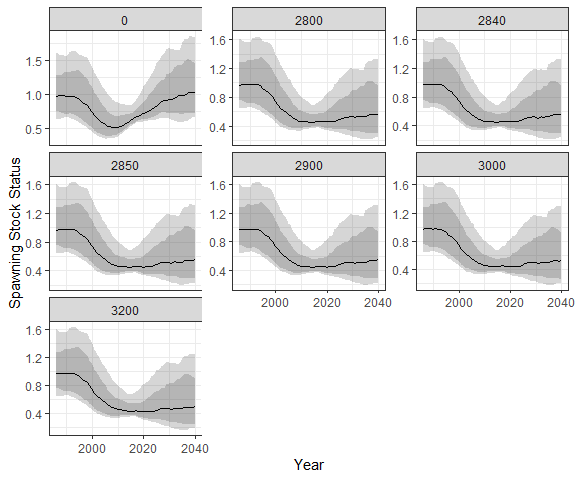

```r
ggplot()+
  geom_ribbon(data=ssbstat,  aes(x=Year, ymin=lwr, ymax=upr), alpha=0.2)+
  geom_ribbon(data=ssbstat, aes(x=Year, ymin=q10, ymax=q90), alpha=0.2)+
geom_line(data=ssbstat, aes(x=Year, y=Med))+
  facet_wrap(~Target/1000, scales = "free_y")+
  scale_color_manual(values = c("red"))+
  scale_fill_manual(values = c("red"))+
  theme_bw()+
  geom_ribbon(data=ssbstatstarts, aes(x=Year, ymin=lwr, ymax=upr), alpha=0.2)+
  geom_ribbon(data=ssbstatstarts, aes(x=Year, ymin=q10, ymax=q90), alpha=0.2)+
  geom_line(data=ssbstatstarts, aes(x=Year, y=Med)) +
  labs(y="Spawning Stock Status")
```